# RM-ANOVA for coevolution with a seed bank - Decomposed data

## Population density data

I have previously consolidated all the data on population density collected for this experiment. This includes:

| Population | What it is | Method of measurement |
| --- | --- | --- |
| spore / mL | host spore density | flow-cytometry: low SYBR population |
| veg / mL | host vegetative cell density | flow-cytometry: high SYBR population |
| cell /mL | total host cell density (spore+veg) | flow-cytometry |
| phage/ mL | total SPO1 phage density (free phage) | qPCR (SYBR) with phage specific primers and lysate serial dilution as standard |

In the first few days of the experiment cell numbers dropped below detection limit in 2 of 3 SNO lines. Missing data cannot be analyzed in RM-ANOVA. I will assign these points the detection limit values.

Points with missing data:

```r
d%>%
  filter(cell.ml<10)
```

| culture | line | Time | seed.bank | phage.ml | spore.ml | veg.ml | cell.ml |
| --- | --- | --- | --- | --- | --- | --- | --- |
| SNO | L2 | 2.5 | none | 531673865 | 1 | 1 | 2 |
| SNO | L3 | 2.5 | none | 697684098 | 1 | 1 | 2 |
| SNO | L2 | 3.0 | none | 3627628662 | 1 | 1 | 2 |

**Flow-cytometry detection limit**

The flow cytometer stop conditions were either $50\mu L$ or 50,000 events, whatever came first.  
In addition, to account for false asignments by noise I required that a gated population have at least 100 events to be taken into account. So the minimal detected population would have 100 cells in $50\mu L$ of analyzed liquid. At this poimt of the experiment we were analyzing x100 diluted samples.

```r
detection.limit <- 100 * (1000/50) * 100
```

## I will use $1X10^5$, half the detection limit dor missing value points

```r
d <- d%>%
  mutate(cell.ml=if_else(cell.ml>10, cell.ml,detection.limit/2))
```

I will re-run the RM-ANOVA analysis on the data decomposed to remove seasona (transfer) fluctuations.

[figure not shown]

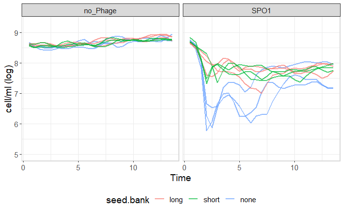

```r
d.decomp.w%>%
    ggplot(aes(x=Time, y=cell.ml))+
      geom_line(aes(group=flask,color=seed.bank), size=1, alpha=0.7)+
      facet_wrap(~phage)+
      theme_bw()+
      panel_border()+
      # scale_y_log10()+
      theme(legend.position = "bottom",
            text=element_text(size=14))+
      ylab("cell/ml (log)")+
      coord_cartesian(ylim = c(5, log10(2e9)))
```

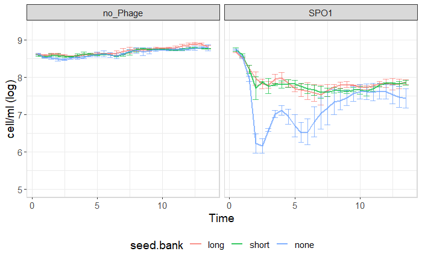

```r
# plot total cells of  data
d.decomp.w%>%
  group_by(phage,seed.bank,Time)%>%
  summarise(n=n(),sd=sd(cell.ml), cell.ml=mean(cell.ml), sem=sd/sqrt(n))%>%
    ggplot(aes(x=Time, y=cell.ml))+
  geom_errorbar(aes(ymin=cell.ml-sem,ymax=cell.ml+sem,color=seed.bank), alpha=0.7)+
      geom_line(aes(color=seed.bank), size=1, alpha=0.7)+
      facet_wrap(~phage)+
      theme_bw()+
      panel_border()+
      # scale_y_log10()+
      theme(legend.position = "bottom",
            text=element_text(size=14))+
      ylab("cell/ml (log)")+
      coord_cartesian(ylim = c(5, log10(2e9)))
```

# Adjusting variable types for lme

In the lme models I will be using the fixd effects need to be secified as factore, in this experiment these ar: *Phage, seed.bank and time*. However for the autocorrelation specification time needs to be specified as an integer. To fulfill both requirements I will use for the time unit the experimental day rather than transfer, since we measured onc a day but twice per transfer. This will be simplty *time x 2*. I will then make fom that a separate varible which will be the factor of the time.

```r
d.4stat <-
  d.decomp.w%>%
  # remove setup data
  filter(Time>=0)%>%
  #make time an integer for correlation structure
  # by converting to days as time unit
  mutate(Time=as.integer(2*Time))%>%
  # for the lme model all fixed effects need to be factors
  mutate(time.fct=as.factor(Time))%>%
  mutate(seed.bank=as.factor(seed.bank))%>%
  mutate(phage=as.factor(phage))
```

## Model selection

### ARMA covariance

This is a combined auto-regeressive model, AR(p) and moving average model, MA(q). I here take a model selection approach to choose these parameters (lowest AIC).

| p | q | aic |
| --- | --- | --- |
| 5 | 2 | -70.35724 |
| 4 | 2 | -69.62819 |
| 7 | 0 | -67.66662 |
| 8 | 0 | -67.24712 |
| 6 | 0 | -66.96215 |
| 3 | 2 | -66.78850 |
| 6 | 1 | -66.60828 |
| 5 | 1 | -63.44717 |
| 5 | 0 | -62.13908 |
| 1 | 1 | -61.33415 |

[output cut: 9 more lines]

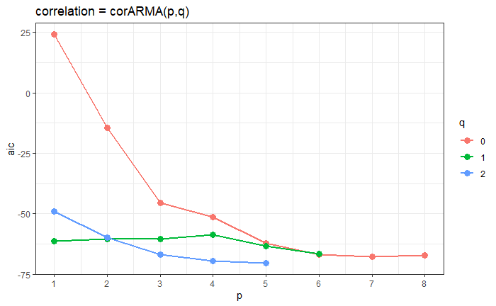

```r
pq.aic%>%arrange(aic)


pq.aic%>%
  mutate(q=as.character(q))%>%
  ggplot(aes(p,aic))+
  geom_line(aes(color=q),size=1)+
  geom_point(aes(color=q),size=3)+
  theme_bw()+
  scale_x_continuous(breaks = 1:10)+
  ggtitle("correlation = corARMA(p,q)")
```

I will test the best 5 models against AR1,

### compare AR1 with ARMA

```r
l.rm <- list()

pq.best <- pq.aic%>%
  slice_min( order_by=aic,n=5)

for (i in 1:nrow(pq.best)){
  l.rm[[i]] <-
    d.4stat%>%
    # looking only at total cells (cell.ml)
    lme(cell.ml ~ phage * seed.bank * time.fct ,
        random = ~1|flask,
        correlation = corARMA(form = ~ Time | flask,
                              p=pq.best$p[i],
                              q=pq.best$q[i]),
        data = .)

}


# add corAR1 to list
l.rm[[i+1]] <-
  d.4stat%>%
  # looking only at total cells (cell.ml)
    lme(cell.ml ~ phage * seed.bank * time.fct ,
        random = ~1|flask,
        correlation = corAR1(form = ~ Time | flask),
        data = .)


# get list order by AIC
aic.l <- sapply(l.rm,AIC)%>%
  sort.list()


# compare models by AIC order
anova.lme(l.rm[[aic.l[6]]],
          l.rm[[aic.l[5]]],
          l.rm[[aic.l[4]]],
          l.rm[[aic.l[3]]],
          l.rm[[aic.l[2]]],
          l.rm[[aic.l[1]]])
```

|  | Model | df | AIC | BIC | logLik | Test | L.Ratio | p-value |
| --- | --- | --- | --- | --- | --- | --- | --- | --- |
| l.rm[[aic.l[6]]] | 1 | 165 | 24.16180 | 647.9845 | 152.9191 |  |  |  |
| l.rm[[aic.l[5]]] | 2 | 170 | -66.96215 | 575.7643 | 203.4811 | 1 vs 2 | 101.12395 | <.0001 |
| l.rm[[aic.l[4]]] | 3 | 172 | -67.24712 | 583.0408 | 205.6236 | 2 vs 3 | 4.28498 | 0.1174 |
| l.rm[[aic.l[3]]] | 4 | 171 | -67.66662 | 578.8405 | 204.8333 | 3 vs 4 | 1.58050 | 0.2087 |
| l.rm[[aic.l[2]]] | 5 | 170 | -69.62819 | 573.0982 | 204.8141 | 4 vs 5 | 0.03843 | 0.8446 |
| l.rm[[aic.l[1]]] | 6 | 171 | -70.35724 | 576.1499 | 206.1786 | 5 vs 6 | 2.72905 | 0.0985 |

```r
#display best model results
tmp <- summary(l.rm[[aic.l[6]]])
tmp$call
```

```
lme.formula(fixed = cell.ml ~ phage * seed.bank * time.fct, data = .,
    random = ~1 | flask, correlation = corAR1(form = ~Time |
        flask))
```

```r
  anova.lme(l.rm[[aic.l[6]]])
```

|  | numDF | denDF | F-value | p-value |
| --- | --- | --- | --- | --- |
| (Intercept) | 1 | 312 | 75735.70 | <.0001 |
| phage | 1 | 12 | 216.49 | <.0001 |
| seed.bank | 2 | 12 | 7.67 | 0.0071 |
| time.fct | 26 | 312 | 15.63 | <.0001 |
| phage:seed.bank | 2 | 12 | 6.26 | 0.0138 |
| phage:time.fct | 26 | 312 | 14.91 | <.0001 |
| seed.bank:time.fct | 52 | 312 | 4.07 | <.0001 |
| phage:seed.bank:time.fct | 52 | 312 | 3.74 | <.0001 |

How sensetive would the result be to model selected?

```r
tmp <- map(l.rm, anova.lme)
tmp1 <- map(l.rm, getCall)

for(i in 1:6){
  print(tmp1[[i]])
  if(i<6) print(paste("p=",pq.best$p[i],"q=",pq.best$q[i]))

  print(tmp[[i]])
}
```

```
lme.formula(fixed = cell.ml ~ phage * seed.bank * time.fct, data = .,
    random = ~1 | flask, correlation = corARMA(form = ~Time |
        flask, p = pq.best$p[i], q = pq.best$q[i]))
[1] "p= 5 q= 2"
```

|  | numDF | denDF | F-value | p-value |
| --- | --- | --- | --- | --- |
| (Intercept) | 1 | 312 | 87386.83 | <.0001 |
| phage | 1 | 12 | 244.50 | <.0001 |
| seed.bank | 2 | 12 | 8.27 | 0.0055 |
| time.fct | 26 | 312 | 20.23 | <.0001 |
| phage:seed.bank | 2 | 12 | 6.58 | 0.0118 |
| phage:time.fct | 26 | 312 | 17.66 | <.0001 |
| seed.bank:time.fct | 52 | 312 | 5.23 | <.0001 |
| phage:seed.bank:time.fct | 52 | 312 | 4.77 | <.0001 |

```
lme.formula(fixed = cell.ml ~ phage * seed.bank * time.fct, data = .,
    random = ~1 | flask, correlation = corARMA(form = ~Time |
        flask, p = pq.best$p[i], q = pq.best$q[i]))
[1] "p= 4 q= 2"
```

|  | numDF | denDF | F-value | p-value |
| --- | --- | --- | --- | --- |
| (Intercept) | 1 | 312 | 71082.75 | <.0001 |
| phage | 1 | 12 | 228.91 | <.0001 |
| seed.bank | 2 | 12 | 7.88 | 0.0065 |
| time.fct | 26 | 312 | 19.95 | <.0001 |
| phage:seed.bank | 2 | 12 | 6.31 | 0.0134 |
| phage:time.fct | 26 | 312 | 18.17 | <.0001 |
| seed.bank:time.fct | 52 | 312 | 5.33 | <.0001 |
| phage:seed.bank:time.fct | 52 | 312 | 4.88 | <.0001 |

```
lme.formula(fixed = cell.ml ~ phage * seed.bank * time.fct, data = .,
    random = ~1 | flask, correlation = corARMA(form = ~Time |
        flask, p = pq.best$p[i], q = pq.best$q[i]))
[1] "p= 7 q= 0"
```

|  | numDF | denDF | F-value | p-value |
| --- | --- | --- | --- | --- |
| (Intercept) | 1 | 312 | 66995.91 | <.0001 |
| phage | 1 | 12 | 220.47 | <.0001 |
| seed.bank | 2 | 12 | 7.78 | 0.0068 |
| time.fct | 26 | 312 | 20.33 | <.0001 |
| phage:seed.bank | 2 | 12 | 6.24 | 0.0139 |
| phage:time.fct | 26 | 312 | 18.17 | <.0001 |
| seed.bank:time.fct | 52 | 312 | 4.97 | <.0001 |
| phage:seed.bank:time.fct | 52 | 312 | 4.49 | <.0001 |

```
lme.formula(fixed = cell.ml ~ phage * seed.bank * time.fct, data = .,
    random = ~1 | flask, correlation = corARMA(form = ~Time |
        flask, p = pq.best$p[i], q = pq.best$q[i]))
[1] "p= 8 q= 0"
```

|  | numDF | denDF | F-value | p-value |
| --- | --- | --- | --- | --- |
| (Intercept) | 1 | 312 | 76563.23 | <.0001 |
| phage | 1 | 12 | 232.37 | <.0001 |
| seed.bank | 2 | 12 | 8.05 | 0.0061 |
| time.fct | 26 | 312 | 20.17 | <.0001 |
| phage:seed.bank | 2 | 12 | 6.43 | 0.0127 |
| phage:time.fct | 26 | 312 | 17.66 | <.0001 |
| seed.bank:time.fct | 52 | 312 | 5.12 | <.0001 |
| phage:seed.bank:time.fct | 52 | 312 | 4.63 | <.0001 |

```
lme.formula(fixed = cell.ml ~ phage * seed.bank * time.fct, data = .,
    random = ~1 | flask, correlation = corARMA(form = ~Time |
        flask, p = pq.best$p[i], q = pq.best$q[i]))
[1] "p= 6 q= 0"
```

|  | numDF | denDF | F-value | p-value |
| --- | --- | --- | --- | --- |
| (Intercept) | 1 | 312 | 78404.08 | <.0001 |
| phage | 1 | 12 | 233.66 | <.0001 |
| seed.bank | 2 | 12 | 8.02 | 0.0061 |
| time.fct | 26 | 312 | 20.53 | <.0001 |
| phage:seed.bank | 2 | 12 | 6.40 | 0.0129 |
| phage:time.fct | 26 | 312 | 18.05 | <.0001 |
| seed.bank:time.fct | 52 | 312 | 5.05 | <.0001 |
| phage:seed.bank:time.fct | 52 | 312 | 4.58 | <.0001 |

```
lme.formula(fixed = cell.ml ~ phage * seed.bank * time.fct, data = .,
    random = ~1 | flask, correlation = corAR1(form = ~Time |
        flask))
```

|  | numDF | denDF | F-value | p-value |
| --- | --- | --- | --- | --- |
| (Intercept) | 1 | 312 | 75735.70 | <.0001 |
| phage | 1 | 12 | 216.49 | <.0001 |
| seed.bank | 2 | 12 | 7.67 | 0.0071 |
| time.fct | 26 | 312 | 15.63 | <.0001 |
| phage:seed.bank | 2 | 12 | 6.26 | 0.0138 |
| phage:time.fct | 26 | 312 | 14.91 | <.0001 |
| seed.bank:time.fct | 52 | 312 | 4.07 | <.0001 |
| phage:seed.bank:time.fct | 52 | 312 | 3.74 | <.0001 |

All models show the same story:  
* The interaction of interaction between phage and time is significant in influencing cell density.

=================

# Host density by host

=================

I will repeat the same anlysis but will treat the seed-bank as a 2-level factor: with (WT host) or without ($\Delta$spoIIE) a seed bank.

```r
# plot raw data
d.4stat%>%
    ggplot(aes(x=Time, y=cell.ml))+
      geom_line(aes(group=flask,color=host), size=1, alpha=0.7)+
      facet_grid(.~phage)+
      theme_bw()+
      panel_border()+
      scale_y_log10()+
      theme(legend.position = "bottom",
            text=element_text(size=14))+
      ylab("cell/ml (log)")+
      coord_cartesian(ylim = c(1e5, 1e10))
```

[output not shown]

## Model selection

### ARMA covariance

This is a combined auto-regeressive model, AR(p) and moving average model, MA(q). I here take a model selection approach to choose these parameters (lowest AIC).

```r
# initalise empty table
pq.aic <- tibble(p=1, q=1,aic=1)%>%
  filter(p>1)

# Playing around with p&q I found the sappce in which the model convergence is limited
for(Q in c(0:2)){
  for (P in c(1:(10-2*Q))){

    #this fllowing combination does not work: "iteration limit reached without convergence"
    if(P>=9 & Q==0) next
    if(P>=7 & Q==1) next

    cur.model <-
        d.4stat%>%
  # looking only at total cells (cell.ml)
    lme(cell.ml ~ phage * seed.bank * time.fct , random = ~1|flask,
            correlation = corARMA(form = ~ Time | flask, p=P,q=Q),
            data = .)

    pq.aic <-
      tibble(p=P, q=Q,aic=AIC(cur.model))%>%
      bind_rows(pq.aic,.)

  }
}
pq.aic%>%arrange(aic)

pq.aic%>%
  mutate(q=as.character(q))%>%
  ggplot(aes(p,aic))+
  geom_line(aes(color=q),size=1)+
  geom_point(aes(color=q),size=3)+
  theme_bw()+
  scale_x_continuous(breaks = 1:10)+
  ggtitle("correlation = corARMA(p,q)")
```

I will test the best 5 models against AR1,

### compare AR1 with ARMA

```r
l.rm <- list()

pq.best <- pq.aic%>%
  slice_min( order_by=aic,n=5)

for (i in 1:nrow(pq.best)){
  l.rm[[i]] <-
    d.4stat%>%
    # looking only at total cells (cell.ml)
    lme(cell.ml ~ phage * host * time.fct , random = ~1|flask,
            correlation = corARMA(form = ~ Time | flask,
                                  p=pq.best$p[i],q=pq.best$q[i]),
            data = .)

}


# add corAR1 to list
l.rm[[i+1]] <-
  d.4stat%>%
  # looking only at total cells (cell.ml)
    lme(cell.ml ~ phage * host * time.fct , random = ~1|flask,
            correlation = corAR1(form = ~ Time | flask),
            data = .)


# get list order by AIC
aic.l <- sapply(l.rm,AIC)%>%
  sort.list()


# compare models by AIC order
anova.lme(l.rm[[aic.l[6]]],
          l.rm[[aic.l[5]]],
          l.rm[[aic.l[4]]],
          l.rm[[aic.l[3]]],
          l.rm[[aic.l[2]]],
          l.rm[[aic.l[1]]])
```

```r
#display best model results
getCall(l.rm[[aic.l[6]]])
  anova.lme(l.rm[[aic.l[6]]])
```

How sensetive would the result be to model selected?

```r
tmp <- map(l.rm, anova.lme)
tmp1 <- map(l.rm, getCall)

for(i in 1:6){
  print(tmp1[[i]])
  if(i<6) print(paste("p=",pq.best$p[i],"q=",pq.best$q[i]))

  print(tmp[[i]])
}
```

=================

# phage density

=================

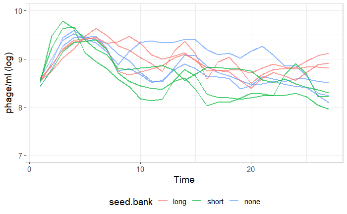

```r
d.4stat%>%
  filter(phage=="SPO1")%>%
    ggplot(aes(x=Time, y=phage.ml))+
      geom_line(aes(group=flask,color=seed.bank), size=1, alpha=0.7)+
      theme_bw()+
      panel_border()+
      # scale_y_log10()+
      theme(legend.position = "bottom",
            text=element_text(size=14))+
      ylab("phage/ml (log)")+
      coord_cartesian(ylim = c(7, 10))
```

Here I will remove time 0, the input phage

```r
d.4stat%>%
  filter(phage=="SPO1")%>%
  filter(Time!=0)%>%
    ggplot(aes(x=Time, y=phage.ml))+
      geom_line(aes(group=flask,color=seed.bank), size=1, alpha=0.7)+
      theme_bw()+
      panel_border()+
      scale_y_log10()+
      theme(legend.position = "bottom",
            text=element_text(size=14))+
      ylab("phage/ml (log)")+
      coord_cartesian(ylim = c(5e7, 1e10))
```

[output not shown]

## Model selection

### ARMA covariance

This is a combined auto-regeressive model, AR(p) and moving average model, MA(q). I here take a model selection approach to choose these parameters (lowest AIC).

| p | q | aic |
| --- | --- | --- |
| 2 | 2 | -9.8104079 |
| 3 | 2 | -7.9533738 |
| 4 | 2 | -5.9622076 |
| 5 | 2 | -4.0263199 |
| 3 | 0 | -3.0575461 |
| 6 | 1 | -2.8205309 |
| 6 | 2 | -2.7394586 |
| 8 | 0 | -2.4640420 |
| 7 | 0 | -1.8552379 |
| 4 | 0 | -1.7165811 |

[output cut: 11 more lines]

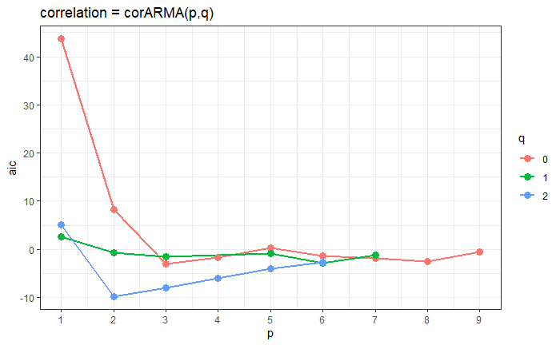

```r
pq.aic%>%arrange(aic)


pq.aic%>%
  mutate(q=as.character(q))%>%
  ggplot(aes(p,aic))+
  geom_line(aes(color=q),size=1)+
  geom_point(aes(color=q),size=3)+
  theme_bw()+
  scale_x_continuous(breaks = 1:10)+
  ggtitle("correlation = corARMA(p,q)")
```

I will test the best 5 models against AR1,

### compare AR1 with ARMA

```r
l.rm <- list()

pq.best <- pq.aic%>%
  slice_min( order_by=aic,n=5)

for (i in 1:nrow(pq.best)){
  l.rm[[i]] <-
    d.4stat%>%
    filter(Time!=0)%>%
    filter(phage=="SPO1")%>%
  # looking only at phages (phage.ml)
    lme(phage.ml ~ seed.bank * time.fct , random = ~1|flask,
            correlation = corARMA(form = ~ 1 | flask,
                                  p=pq.best$p[i],q=pq.best$q[i]),
            data = .)

}


# add corAR1 to list
l.rm[[i+1]] <-
  d.4stat%>%
  filter(phage=="SPO1")%>%
  filter(Time!=0)%>%
 # looking only at phages (phage.ml)
    lme(phage.ml ~ seed.bank * time.fct , random = ~1|flask,
            correlation = corAR1(form = ~ 1 | flask),
            data = .)


# get list order by AIC
aic.l <- sapply(l.rm,AIC)%>%
  sort.list()


# compare models by AIC order
anova.lme(l.rm[[aic.l[6]]],
          l.rm[[aic.l[5]]],
          l.rm[[aic.l[4]]],
          l.rm[[aic.l[3]]],
          l.rm[[aic.l[2]]],
          l.rm[[aic.l[1]]])
```

|  | Model | df | AIC | BIC | logLik | Test | L.Ratio | p-value |
| --- | --- | --- | --- | --- | --- | --- | --- | --- |
| l.rm[[aic.l[6]]] | 1 | 84 | 43.71089 | 303.0690 | 62.14456 |  |  |  |
| l.rm[[aic.l[5]]] | 2 | 86 | -3.05755 | 262.4757 | 87.52877 | 1 vs 2 | 50.76843 | <.0001 |
| l.rm[[aic.l[4]]] | 3 | 90 | -4.02632 | 273.8573 | 92.01316 | 2 vs 3 | 8.96877 | 0.0619 |
| l.rm[[aic.l[3]]] | 4 | 89 | -5.96221 | 268.8339 | 91.98110 | 3 vs 4 | 0.06411 | 0.8001 |
| l.rm[[aic.l[2]]] | 5 | 88 | -7.95337 | 263.7551 | 91.97669 | 4 vs 5 | 0.00883 | 0.9251 |
| l.rm[[aic.l[1]]] | 6 | 87 | -9.81041 | 258.8105 | 91.90520 | 5 vs 6 | 0.14297 | 0.7054 |

```r
#display best model results
getCall(l.rm[[aic.l[6]]])
```

```
lme.formula(fixed = phage.ml ~ seed.bank * time.fct, data = .,
    random = ~1 | flask, correlation = corAR1(form = ~1 | flask))
```

```r
  anova(l.rm[[aic.l[6]]])
```

|  | numDF | denDF | F-value | p-value |
| --- | --- | --- | --- | --- |
| (Intercept) | 1 | 156 | 46007.60 | <.0001 |
| seed.bank | 2 | 6 | 6.07 | 0.0362 |
| time.fct | 26 | 156 | 13.47 | <.0001 |
| seed.bank:time.fct | 52 | 156 | 1.85 | 0.0020 |

**There is a significant effect of seed.bank and time on phage population density.**

How sensetive would the result be to model selected?

```r
tmp <- map(l.rm, anova.lme)
tmp1 <- map(l.rm, getCall)

for(i in 1:6){
  print(tmp1[[i]])
  if(i<6) print(paste("p=",pq.best$p[i],"q=",pq.best$q[i]))

  print(tmp[[i]])
}
```

```
lme.formula(fixed = phage.ml ~ seed.bank * time.fct, data = .,
    random = ~1 | flask, correlation = corARMA(form = ~1 | flask,
        p = pq.best$p[i], q = pq.best$q[i]))
[1] "p= 2 q= 2"
```

|  | numDF | denDF | F-value | p-value |
| --- | --- | --- | --- | --- |
| (Intercept) | 1 | 156 | 38585.43 | <.0001 |
| seed.bank | 2 | 6 | 5.17 | 0.0496 |
| time.fct | 26 | 156 | 12.27 | <.0001 |
| seed.bank:time.fct | 52 | 156 | 1.82 | 0.0026 |

```
lme.formula(fixed = phage.ml ~ seed.bank * time.fct, data = .,
    random = ~1 | flask, correlation = corARMA(form = ~1 | flask,
        p = pq.best$p[i], q = pq.best$q[i]))
[1] "p= 3 q= 2"
```

|  | numDF | denDF | F-value | p-value |
| --- | --- | --- | --- | --- |
| (Intercept) | 1 | 156 | 39380.29 | <.0001 |
| seed.bank | 2 | 6 | 5.29 | 0.0474 |
| time.fct | 26 | 156 | 12.25 | <.0001 |
| seed.bank:time.fct | 52 | 156 | 1.82 | 0.0027 |

```
lme.formula(fixed = phage.ml ~ seed.bank * time.fct, data = .,
    random = ~1 | flask, correlation = corARMA(form = ~1 | flask,
        p = pq.best$p[i], q = pq.best$q[i]))
[1] "p= 4 q= 2"
```

|  | numDF | denDF | F-value | p-value |
| --- | --- | --- | --- | --- |
| (Intercept) | 1 | 156 | 39222.45 | <.0001 |
| seed.bank | 2 | 6 | 5.28 | 0.0475 |
| time.fct | 26 | 156 | 12.25 | <.0001 |
| seed.bank:time.fct | 52 | 156 | 1.82 | 0.0026 |

```
lme.formula(fixed = phage.ml ~ seed.bank * time.fct, data = .,
    random = ~1 | flask, correlation = corARMA(form = ~1 | flask,
        p = pq.best$p[i], q = pq.best$q[i]))
[1] "p= 5 q= 2"
```

|  | numDF | denDF | F-value | p-value |
| --- | --- | --- | --- | --- |
| (Intercept) | 1 | 156 | 39992.71 | <.0001 |
| seed.bank | 2 | 6 | 5.34 | 0.0466 |
| time.fct | 26 | 156 | 12.28 | <.0001 |
| seed.bank:time.fct | 52 | 156 | 1.81 | 0.0027 |

```
lme.formula(fixed = phage.ml ~ seed.bank * time.fct, data = .,
    random = ~1 | flask, correlation = corARMA(form = ~1 | flask,
        p = pq.best$p[i], q = pq.best$q[i]))
[1] "p= 3 q= 0"
```

|  | numDF | denDF | F-value | p-value |
| --- | --- | --- | --- | --- |
| (Intercept) | 1 | 156 | 43734.21 | <.0001 |
| seed.bank | 2 | 6 | 5.41 | 0.0455 |
| time.fct | 26 | 156 | 12.49 | <.0001 |
| seed.bank:time.fct | 52 | 156 | 1.79 | 0.0032 |

```
lme.formula(fixed = phage.ml ~ seed.bank * time.fct, data = .,
    random = ~1 | flask, correlation = corAR1(form = ~1 | flask))
```

|  | numDF | denDF | F-value | p-value |
| --- | --- | --- | --- | --- |
| (Intercept) | 1 | 156 | 46007.60 | <.0001 |
| seed.bank | 2 | 6 | 6.07 | 0.0362 |
| time.fct | 26 | 156 | 13.47 | <.0001 |
| seed.bank:time.fct | 52 | 156 | 1.85 | 0.0020 |

All models show the same story: Seed bank X time significant for phage.

=================

# spore density

=================

```r
d.4stat%>%
  filter(host=="WT")%>%
       ggplot(aes(x=Time, y=spore.ml))+
      geom_line(aes(group=flask,color=seed.bank), size=1, alpha=0.7)+
  geom_hline(yintercept = detection.limit, color="red")+
  geom_label(label="detection limit", x=10, y=log10(detection.limit), color="red")+
      facet_wrap(~phage)+
      theme_bw()+
      panel_border()+
      scale_y_log10()+
      theme(legend.position = "bottom",
            text=element_text(size=14))+
      ylab("spore/ml (log)")+
      coord_cartesian(ylim = c(1e5, 2e9))
```

[output not shown]

All points usable.

## Model selection

### ARMA covariance

This is a combined auto-regeressive model, AR(p) and moving average model, MA(q). I here take a model selection approach to choose these parameters (lowest AIC).

```r
# initalise empty table
pq.aic <- tibble(p=1, q=1,aic=1)%>%
  filter(p>1)

# Playing around with p&q I found the space in which the model convergence is limited
for(Q in c(0:2)){
  for (P in c(1:(10-2*Q))){

        #this fllowing combination does not work: "iteration limit reached without convergence"
    if(P>=6 & Q==2) next

    cur.model <-
        d.4stat%>%
      filter(host=="WT")%>%
  # looking only at total cells (cell.ml)
    lme(spore.ml ~ phage*seed.bank * time.fct , random = ~1|flask,
            correlation = corARMA(form = ~ Time | flask, p=P,q=Q),
            data = .)

    pq.aic <-
      tibble(p=P, q=Q,aic=AIC(cur.model))%>%
      bind_rows(pq.aic,.)

  }
}

pq.aic%>%arrange(aic)

pq.aic%>%
  mutate(q=as.character(q))%>%
  ggplot(aes(p,aic))+
  geom_line(aes(color=q),size=1)+
  geom_point(aes(color=q),size=3)+
  theme_bw()+
  scale_x_continuous(breaks = 1:10)+
  ggtitle("correlation = corARMA(p,q)")
```

I will test the best 5 models against AR1,

### compare AR1 with ARMA

```r
l.rm <- list()

pq.best <- pq.aic%>%
  slice_min( order_by=aic,n=5)

for (i in 1:nrow(pq.best)){
  l.rm[[i]] <-
        d.4stat%>%
      filter(host=="WT")%>%
  # looking only at total spore (spore.ml)
    lme(spore.ml ~ phage*seed.bank * time.fct , random = ~1|flask,
        correlation = corARMA(form = ~ 1 | flask,
                              p=pq.best$p[i],q=pq.best$q[i]),
            data = .)

}


# add corAR1 to list
l.rm[[i+1]] <-
        d.4stat%>%
      filter(host=="WT")%>%
  # looking only at total spore (spore.ml)
    lme(spore.ml ~ phage*seed.bank * time.fct , random = ~1|flask,
            correlation = corAR1(form = ~ 1 | flask),
            data = .)


# get list order by AIC
aic.l <- sapply(l.rm,AIC)%>%
  sort.list()


# compare models by AIC order
anova.lme(l.rm[[aic.l[6]]],
          l.rm[[aic.l[5]]],
          l.rm[[aic.l[4]]],
          l.rm[[aic.l[3]]],
          l.rm[[aic.l[2]]],
          l.rm[[aic.l[1]]])
```

```r
#display best model results
getCall(l.rm[[aic.l[6]]])
  anova.lme(l.rm[[aic.l[6]]])
```

How sensetive would the result be to model selected?

```r
tmp <- map(l.rm, anova.lme)
tmp1 <- map(l.rm, getCall)

for(i in 1:6){
  print(tmp1[[i]])
  if(i<6) print(paste("p=",pq.best$p[i],"q=",pq.best$q[i]))

  print(tmp[[i]])
}
```

=================

# percent spore

=================

```r
d.4stat <- d.4stat%>%
  mutate(perc.spore=100*spore.ml/cell.ml)

d.4stat%>%
  filter(host=="WT")%>%
    ggplot(aes(x=Time, y=perc.spore))+
    geom_line(aes(group=flask,color=seed.bank), size=1, alpha=0.7)+
    theme_bw()+
    panel_border()+
  facet_wrap(~phage)+
  theme(legend.position = "bottom",
            text=element_text(size=14))+
  ylab("% spore")+
  ylim(0,100)
```

[output not shown]

All points usable.

## Model selection

### ARMA covariance

This is a combined auto-regeressive model, AR(p) and moving average model, MA(q). I here take a model selection approach to choose these parameters (lowest AIC).

```r
# initalise empty table
pq.aic <- tibble(p=1, q=1,aic=1)%>%
  filter(p>1)

# Playing around with p&q I found the space in which the model convergence is limited
for(Q in c(0:2)){
  for (P in c(1:(10-2*Q))){

        #this fllowing combination does not work: "iteration limit reached without convergence"
    if(P>=10 & Q==0) next
    if(P>=6 & Q==1) next
    if(P>=6 & Q==2) next

    cur.model <-
        d.4stat%>%
      filter(host=="WT")%>%
  # looking only at total cells (cell.ml)
    lme(perc.spore ~ phage*seed.bank * time.fct , random = ~1|flask,
            correlation = corARMA(form = ~ Time | flask, p=P,q=Q),
            data = .)

    pq.aic <-
      tibble(p=P, q=Q,aic=AIC(cur.model))%>%
      bind_rows(pq.aic,.)

  }
}

pq.aic%>%arrange(aic)

pq.aic%>%
  mutate(q=as.character(q))%>%
  ggplot(aes(p,aic))+
  geom_line(aes(color=q),size=1)+
  geom_point(aes(color=q),size=3)+
  theme_bw()+
  scale_x_continuous(breaks = 1:10)+
  ggtitle("correlation = corARMA(p,q)")
```

I will test the best 5 models against AR1,

### compare AR1 with ARMA

```r
l.rm <- list()

pq.best <- pq.aic%>%
  slice_min( order_by=aic,n=5)

for (i in 1:nrow(pq.best)){
  l.rm[[i]] <-
        d.4stat%>%
      filter(host=="WT")%>%
  # looking only at total spore (spore.ml)
    lme(perc.spore ~ phage*seed.bank * time.fct , random = ~1|flask,
        correlation = corARMA(form = ~ Time | flask,
                              p=pq.best$p[i],q=pq.best$q[i]),
            data = .)

}


# add corAR1 to list
l.rm[[i+1]] <-
        d.4stat%>%
      filter(host=="WT")%>%
  # looking only at total spore (spore.ml)
    lme(perc.spore ~ phage*seed.bank * time.fct , random = ~1|flask,
            correlation = corAR1(form = ~ Time | flask),
            data = .)


# get list order by AIC
aic.l <- sapply(l.rm,AIC)%>%
  sort.list()


# compare models by AIC order
anova.lme(l.rm[[aic.l[6]]],
          l.rm[[aic.l[5]]],
          l.rm[[aic.l[4]]],
          l.rm[[aic.l[3]]],
          l.rm[[aic.l[2]]],
          l.rm[[aic.l[1]]])
```

```r
#display best model results
getCall(l.rm[[aic.l[6]]])

  anova.lme(l.rm[[aic.l[6]]])
```

How sensetive would the result be to model selected?

```r
tmp <- map(l.rm, anova.lme)
tmp1 <- map(l.rm, getCall)

for(i in 1:6){
  print(tmp1[[i]])
  if(i<6) print(paste("p=",pq.best$p[i],"q=",pq.best$q[i]))

  print(tmp[[i]])
}
```

=================

# Veg cells

=================

```r
d.4stat%>%
    ggplot(aes(x=Time, y=veg.ml))+
      geom_line(aes(group=flask,color=seed.bank), size=1, alpha=0.7)+
  geom_hline(yintercept = detection.limit, color="red")+
  geom_label(label="detection limit", x=10, y=log10(detection.limit), color="red")+
      facet_wrap(~phage)+
      theme_bw()+
      panel_border()+
      scale_y_log10()+
      theme(legend.position = "bottom",
            text=element_text(size=14))+
      ylab("veg. cell/ml (log)")+
      coord_cartesian(ylim = c(1e5, 2e9))
```

[output not shown]

All points usable.

## Model selection

### ARMA covariance

This is a combined auto-regeressive model, AR(p) and moving average model, MA(q). I here take a model selection approach to choose these parameters (lowest AIC).

```r
# initalise empty table
pq.aic <- tibble(p=1, q=1,aic=1)%>%
  filter(p>1)

# Playing around with p&q I found the space in which the model convergence is limited
for(Q in c(0:2)){
  for (P in c(1:(10-2*Q))){

        #this fllowing combination does not work: "iteration limit reached without convergence"
    if(P>=9 & Q==0) next
    if(P>=8 & Q==1) next
    # if(P==1 & Q==2) next
    # if(P==3 & Q==2) next

    cur.model <-
        d.4stat%>%
  # looking only at veg cells (veg.ml)
    lme(veg.ml ~ phage*seed.bank * time.fct , random = ~1|flask,
            correlation = corARMA(form = ~ Time | flask, p=P,q=Q),
            data = .)

    pq.aic <-
      tibble(p=P, q=Q,aic=AIC(cur.model))%>%
      bind_rows(pq.aic,.)

  }
}

pq.aic%>%arrange(aic)

pq.aic%>%
  mutate(q=as.character(q))%>%
  ggplot(aes(p,aic))+
  geom_line(aes(color=q),size=1)+
  geom_point(aes(color=q),size=3)+
  theme_bw()+
  scale_x_continuous(breaks = 1:10)+
  ggtitle("correlation = corARMA(p,q)")
```

I will test the best 5 models against AR1,

### compare AR1 with ARMA

```r
l.rm <- list()

pq.best <- pq.aic%>%
  slice_min( order_by=aic,n=5)

for (i in 1:nrow(pq.best)){
  l.rm[[i]] <-
        d.4stat%>%
  # looking only at veg cells (veg.ml)
    lme(veg.ml ~ phage*seed.bank * time.fct , random = ~1|flask,
        correlation = corARMA(form = ~ Time | flask,
                              p=pq.best$p[i],q=pq.best$q[i]),
            data = .)

}


# add corAR1 to list
l.rm[[i+1]] <-
        d.4stat%>%
  # looking only at veg cells (veg.ml)
    lme(veg.ml ~ phage*seed.bank * time.fct , random = ~1|flask,
            correlation = corAR1(form = ~ Time | flask),
            data = .)


# get list order by AIC
aic.l <- sapply(l.rm,AIC)%>%
  sort.list()


# compare models by AIC order
anova.lme(l.rm[[aic.l[6]]],
          l.rm[[aic.l[5]]],
          l.rm[[aic.l[4]]],
          l.rm[[aic.l[3]]],
          l.rm[[aic.l[2]]],
          l.rm[[aic.l[1]]])
```

```r
#display best model results
getCall(l.rm[[aic.l[6]]])

  anova.lme(l.rm[[aic.l[6]]])
```

How sensetive would the result be to model selected?

```r
tmp <- map(l.rm, anova.lme)
tmp1 <- map(l.rm, getCall)

for(i in 1:6){
  print(tmp1[[i]])
  if(i<6) print(paste("p=",pq.best$p[i],"q=",pq.best$q[i]))

  print(tmp[[i]])
}
```